# Lightcurve Tutorial

SunPy currently supports the creating of time series, or lightcurves, from a number of data sources, including GOES, SDO/EVE, Proba-2/LYRA, the Nobeyama Radioheliograph (NoRH), and RHESSI. Here we demonstrate how lightcurves may be created and used in solar analysis.

```python
#suppress some chatter from the terminal for example purposes
import warnings
warnings.filterwarnings('ignore')

import sunpy
from sunpy import lightcurve
```

```python
import matplotlib.pyplot as plt
#the next line just makes matplotlib plots appear inline instead of in separate windows
%matplotlib inline
```

# Example: The 2011 June 7 solar flare

Let's create some lightcurves for the solar flare of 2011 June 7.

### Creating the lightcurves

```python
goes_lightcurve = lightcurve.GOESLightCurve.create('2011-06-07 06:00','2011-06-07 08:00')
hsi_lightcurve = lightcurve.RHESSISummaryLightCurve.create('2011-06-07 06:00','2011-06-07 08:00')
```

```python
lyra_lightcurve_fullday = lightcurve.LYRALightCurve.create('2011-06-07')
```

At present, some data sources allow queries by time range (like GOES), but some others only allow queries by date (like LYRA), generating a full-day lightcurve. However, we can easily trim the lightcurve to the desired range using the truncate command:

```python
lyra_lightcurve = lyra_lightcurve_fullday.truncate('2011-06-07 06:00','2011-06-07 08:00')
```

### Making quicklook plots

Now let's plot the GOES and LYRA lightcurves using their quicklook plot commands:

[figure not shown]

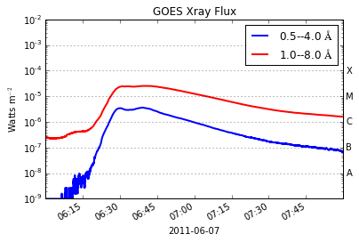

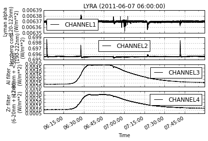

```python
#the peek() command makes a quicklook plot of the lightcurve with some default parameters
goes_lightcurve.peek()
lyra_lightcurve.peek()
```

### Accessing and using the data

More custom plots can be made easily by accessing the data in the lightcurve object. Both the time information and the data are contained within the lightcurve.data object, which is a pandas dataframe. We can see what data is contained in the dataframe by finding which keys it contains:

```python
print lyra_lightcurve.data.keys()
```

```
Index([u'CHANNEL1', u'CHANNEL2', u'CHANNEL3', u'CHANNEL4'], dtype='object')
```

The metadata (or header information) for the lightcurve is held in a python dictionary format. We can access the metadata like this:

```python
print lyra_lightcurve.meta
```

[output not shown]

Now let's make a custom plot of the Aluminium (channel 3) and Zirconium (channel 4) filter data from LYRA.

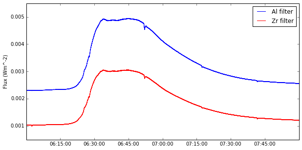

```python
plt.figure(1,figsize=(10,5))
plt.plot(lyra_lightcurve.data.index,lyra_lightcurve.data['CHANNEL3'],color='blue',label='Al filter')
plt.plot(lyra_lightcurve.data.index,lyra_lightcurve.data['CHANNEL4'],color='red',label='Zr filter')
plt.ylim([0.0005,0.0055])
plt.ylabel('Flux (Wm^-2)')
plt.legend()
plt.show()
```

### Analysing lightcurve data

Let's see how well the LYRA lightcurves correlate with each other. For this, we need to use functions in numpy.

```python
import numpy as np
```

```python
cross_correlation = np.correlate(lyra_lightcurve.data['CHANNEL3'],lyra_lightcurve.data['CHANNEL4'])
print cross_correlation
```

```
[ 0.96242571]
```

We can find the point in time of maximum emission for each channel, and compare it with the maximum in the GOES long (1-8A) and short (0.5-4A) channel emission.

```python
timeofmax_goes_long = goes_lightcurve.data['xrsb'].idxmax()
timeofmax_goes_short = goes_lightcurve.data['xrsa'].idxmax()
timeofmax_lyra_al = lyra_lightcurve.data['CHANNEL3'].idxmax()
timeofmax_lyra_zr = lyra_lightcurve.data['CHANNEL4'].idxmax()
print 'GOES long: ', timeofmax_goes_long
print 'GOES short: ', timeofmax_goes_short
print 'LYRA Al: ', timeofmax_lyra_al
print 'LYRA Zr: ', timeofmax_lyra_zr
```

```
GOES long:  2011-06-07 06:41:24.118999
GOES short:  2011-06-07 06:39:00.761999
LYRA Al:  2011-06-07 06:44:47.915000
LYRA Zr:  2011-06-07 06:44:44.464880
```

We can see that the GOES short channel peaks first at 06:39:00, followed by the GOES long channel at 06:41:24, while the LYRA emission peaks later at around 06:44:45. We could add this information to our plot like this:

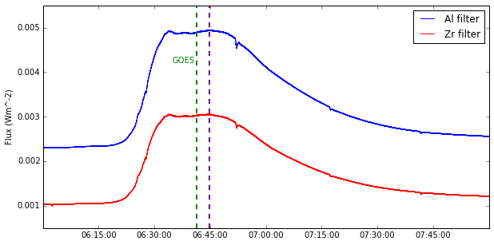

```python
plt.figure(2,figsize=(10,5))
plt.plot(lyra_lightcurve.data.index,lyra_lightcurve.data['CHANNEL3'],color='blue',label='Al filter')
plt.plot(lyra_lightcurve.data.index,lyra_lightcurve.data['CHANNEL4'],color='red',label='Zr filter')
plt.ylim([0.0005,0.0055])
plt.ylabel('Flux (Wm^-2)')

plt.axvline(timeofmax_lyra_al,color='blue',linestyle='dashed',linewidth=2)
plt.axvline(timeofmax_lyra_zr,color='red',linestyle='dashed')
plt.axvline(timeofmax_goes_long,color='green',linestyle='dashed',linewidth=2)
plt.figtext(0.35,0.7,'GOES',color='green')

plt.legend()
plt.show()
```

We can see this more easily by making a multi-panel plot that includes the GOES and RHESSI data.

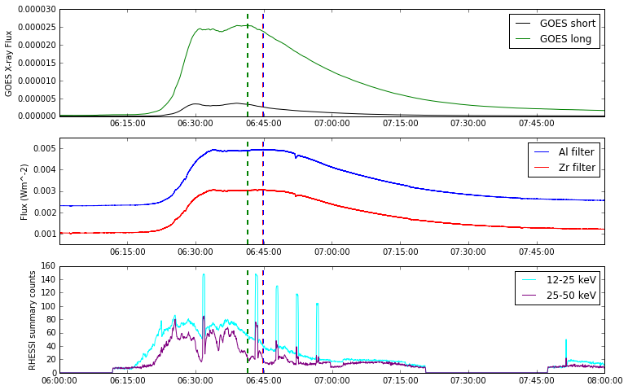

```python
plt.figure(3,figsize=(12,8))
#first subplot - let's plot the GOES data
plt.subplot(3,1,1)
plt.plot(goes_lightcurve.data.index,goes_lightcurve.data['xrsa'],color='black',label='GOES short')
plt.plot(goes_lightcurve.data.index,goes_lightcurve.data['xrsb'],color='green',label='GOES long')
plt.ylabel('GOES X-ray Flux')
plt.legend()

#add the vertical lines
plt.axvline(timeofmax_lyra_al,color='blue',linestyle='dashed',linewidth=2)
plt.axvline(timeofmax_lyra_zr,color='red',linestyle='dashed')
plt.axvline(timeofmax_goes_long,color='green',linestyle='dashed',linewidth=2)

#second subplot - plot the LYRA data again
plt.subplot(3,1,2)
plt.plot(lyra_lightcurve.data.index,lyra_lightcurve.data['CHANNEL3'],color='blue',label='Al filter')
plt.plot(lyra_lightcurve.data.index,lyra_lightcurve.data['CHANNEL4'],color='red',label='Zr filter')
plt.ylim([0.0005,0.0055])
plt.ylabel('Flux (Wm^-2)')
plt.legend()

#add the vertical lines
plt.axvline(timeofmax_lyra_al,color='blue',linestyle='dashed',linewidth=2)
plt.axvline(timeofmax_lyra_zr,color='red',linestyle='dashed')
plt.axvline(timeofmax_goes_long,color='green',linestyle='dashed',linewidth=2)

#third subplot - plot the RHESSI summary data in select channels
plt.subplot(3,1,3)
plt.plot(hsi_lightcurve.data.index,hsi_lightcurve.data['12 - 25 keV'],color='cyan',label='12-25 keV')
plt.plot(hsi_lightcurve.data.index,hsi_lightcurve.data['25 - 50 keV'],color='purple',label='25-50 keV')
plt.ylabel('RHESSI summary counts')
plt.legend()

#add the vertical lines
plt.axvline(timeofmax_lyra_al,color='blue',linestyle='dashed',linewidth=2)
plt.axvline(timeofmax_lyra_zr,color='red',linestyle='dashed')
plt.axvline(timeofmax_goes_long,color='green',linestyle='dashed',linewidth=2)

plt.show()
```

We can see that the RHESSI summary data includes the effects of attenuator state changes.